# Survival Analysis Notes

dizhen

4/28/2020

# Survival Analysis

## 1. Introduction: Datasets and Survival analysis in general

The main packages needed.

```r
library("survival")
library("ranger")
library("ggfortify")
library("lubridate")
library("flexsurv")
```

CRAN Task View: Survival Analysis: https://cran.r-project.org/web/views/Survival.html

survival package: a widely used package for Survival Analysis: https://cran.r-project.org/web/packages/survival/index.html

1. The three main topics of survival analysis
- Estimating the underlying survival function with life tables and Kaplan-Meier curves
- Comparing the survival time of two or more groups with Log-rank test.
- Desscribing the effect of covariates with Cox proportional hazards regression, survival trees and random forests.
2. Three primary terms of survival analysis
- Event ($\sigma_i$):
  - The event of interest depends on the study or the dataset.
  - E.g. Failure, death, disease, recovery, decay, development.
  - Binary: 0 or 1.
- Time($t_i$):
  - The time interval between the begining of a study and the occurrence of the event.
- Censoring($c_i$):
  - Occurs if a subject doesn’t have an event during the observational time.
3. Typical questions to be answered with survival analysis
- What is the proportion of a population surviving past a centain time?
- Of those that survive, at what rate will they die or fail
- Can multiple causes of death or failure be taken into account?
- What is the average survival time?
- How do particular circumstances or characteristics change the probability of survival?

```r
## Import prostate_cancer as prost
## A study on prostate cancer patients

# Providing column names
# colnames(prost) = c("patient", "treatment", "time", "status", "age", "sh", "size", "index")
# save(prost, file = "prost.RData")
load("prost.RData")
head(prost)
```

```
##   patient treatment time status age   sh size index
## 1       1         1   65      0  67 13.4   34     8
## 2       2         2   61      0  60 14.6    4    10
## 3       3         2   60      0  77 15.6    3     8
## 4       4         1   58      0  64 16.2    6     9
## 5       5         2   51      0  65 14.1   21     9
## 6       6         1   51      0  61 13.5    8     8
```

4. The ideal data structure for survival analysis: Outliers and missing values are replaced.

Propoer time format:

- Data-time values
- Time periods are calculated

### Overview

1. Non-parametric models:
- Kaplan-Meier estimator
- Logrank test
2. The survival object
- Function “Surv()”
- Defines the relationship between event and time
3. Kaplan-Meier plot: A step plot showing the decline in survival probability over time.
- Additional binary covariate selected with the logrank test.

### The Survival function

a.k.a. “Reliability function”, “Survival function”, “Complementary cumulative distribution function”.

1. The Survival function
   $$S(t) = P(T>t) = 1-F(t)$$
- $S(t)$: The survival estimation
- $P$: Probability
- $T$: SUrvival time
- $t$: Specified time point
- $F(t)$: The inverse called cumulative distribution function
- Related to the hazard function $h(t)$ or $\lambda(t)$
2. The Hazard Rate

$$h(t) = lim_{\delta t \rightarrow 0} \frac{1}{\delta t}P(t \leq T < t+\delta t|T\geq t)$$

- $h(t)$: The risk of an event at time point t.
- $P$: The probability that a subject has an event.
- Instantaneous death rate/ intensity rate/ force of mortality/ hazard rate
- Divide the probability ($P$) of an individual’s survivor time ($T$) within an interval by the interval length($\delta t$)
3. Integrated or Cumulative hazard

$$H(t) = -log S(t)$$

- $H(t)$ or $\Lambda (t)$: Cumulative hazard
- Adding the rate of risk per time unit up for every time unit passed
- $t$: The time units already passed
- $S(t)$: The survival function
4. Estimating the Survival Function
- Kaplan-Meier estimator( non-parametric)
- Exponential survial curve. The probability of an event is the same at any time point
- Weibull distribution with optional pre-set probabilities in relation to time
- Normal distribution (mean)

### The survival object

`Surv(time, time2, event, type=c('right', 'left', 'interval', 'counting', 'interval2', 'mstate'), origin=0)`

time: follow up time (for right censored data); starting time (for interval data).

time2: ending time (for interval data)

event: 0=alive, 1=dead (for righer censored); 0=right censored, 1=event,2=left censored, 3=interval censored (for interval data).

type: “right”,“left”,“counting”,“interval”, etc.

```r
### The fundamental Surv function

library(survival)

Surv(prost$time, prost$status)
```

```
##  [1] 65+ 61+ 60+ 58+ 51+ 51+ 14  43+ 16+ 52+ 59  55+ 68+ 51   2+ 67+ 66+ 66  28+
## [20] 50  69  67  65+ 24+ 45+ 64+ 61+ 26  42  57+ 70+  5+ 54+ 36  70  67+ 23+ 52
## [39] 65+ 24  45+ 64+ 61  21  22  37+ 51  12+ 67+ 61+ 66  65+ 50  35  67  65+ 33+
## [58] 45+ 62+ 61+ 36  42  57+
```

### The Kaplan-Meier estimator

1. Calculating the estimator of survival

$$\hat{S}(t) = \prod_{i:t_i\leq t}(1-\frac{d_i}{n_i})$$

- $\hat{S}(t)$: The estimator of survival to time point t and beyond
- $t_i$: The time point where at least one event happened
- $d_i$: The number of events happening at time point t.
- $n_i$: The number of individuals known to survive.
2. The Kaplan-Meier estimator
- A non-parametric statistic used to estimate the urvival function
  - No underlying assumptions (parameters)
  - Declining step plot
- Incorporates censored data
- It cannot incorporate covariates
  - Comparison plot is possible
- Two variables required in the data:
  - Status of the event and time indicator -Additional group indicator
3. Kaplan-Meier Plot

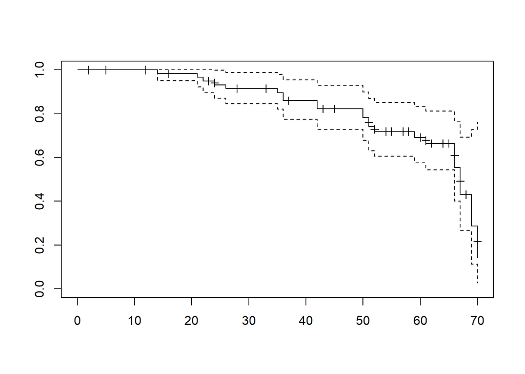

```r
# Simple Kaplan Meier plot

mykm1 <- survfit(Surv(time, status) ~ 1, data = prost)

plot(mykm1, mark.time = TRUE)
```

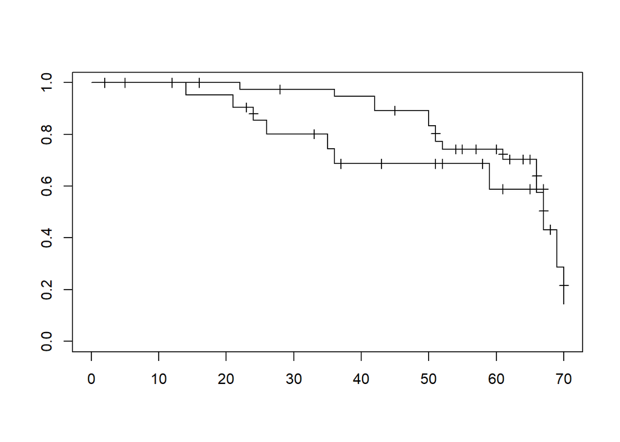

```r
# Stratified KM plot

mykm2 <- survfit(Surv(time, status) ~ treatment, data = prost) ## alternative 2 line chart

plot(mykm2, mark.time = TRUE)
```

4. Advanced Kaplan-Meier Plots
- Libraries “ggplot2” and “ggfortify” - Function “autoplot()”
- Libraries “ggplot2” and “survminer” - Function “ggsurvplot()”

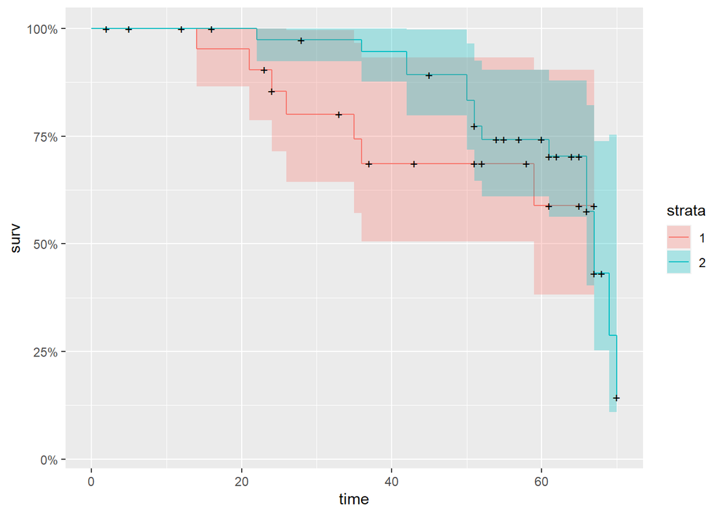

```r
# Advanced plot

library(ggfortify)

autoplot(mykm2)
```

### The logrank test

1. The logrank test
- Allow to compare the survival distribution of two groups
  - “Which treatment has a better survival probability?”
- Non-parametric test -Best used on right skewed data with censored events -Alternative: Wilcoxon Rank Sum Test
- Compares the estimates of the hazard functions of the two groups at each observed event time
  1. Computes the observed and expected number of events
  2. Results are added up to get a total across all time points
2. The logrank test statistic

$$Z = \frac{\sum^J_{j=1}(O_{1j}-E_{1j})}{\sqrt{\sum^J_{j=1}V_j}} \overset{d}{\rightarrow} N(0,1)$$

- Test statistic
  - Normal distribution (mean ~ 0)
  - Standard deviation(1)
- Null hypothesis: The hazard rate in each group is similar
  - Rejected if the test statistic of Z is not normally distributed.
3. Assumption of the logrank test
- Censoring is unrelated to the group setup
- Survival probabilities are the same for all subjects
- The events happened at the time specified.

4 Implementation of logrank test in R

```r
# Log Rank Test

survival::survdiff(survival::Surv(prost$time, prost$status) ~ prost$treatment)
```

```
## Call:
## survival::survdiff(formula = survival::Surv(prost$time, prost$status) ~
##     prost$treatment)
##
##                    N Observed Expected (O-E)^2/E (O-E)^2/V
## prost$treatment=1 23        7     5.13     0.686     0.958
## prost$treatment=2 40       16    17.87     0.197     0.958
##
##  Chisq= 1  on 1 degrees of freedom, p= 0.3
```

p is not significant, meaning there is no difference in the survival probability of both treatment.

### Practice

Kaplan-Meier estimator and logrank test

Dataset: motorette from “SMPracticals” (Times to failure of motorettes tested at different temperatures.)

- Modeling the data
  - Generate a Kaplan-Meier plot
  - Get a logrank test and implement the temperature vairable
- Does the temperature have an effect on the failure rate?
  - Create a new binary indicator “temp_binary” _ Threshold 180 F

```r
# Exercise Kaplan Meier

library(SMPracticals)
head(motorette)
```

```
##     x cens    y
## 1 150    0 8064
## 2 150    0 8064
## 3 150    0 8064
## 4 150    0 8064
## 5 150    0 8064
## 6 150    0 8064
```

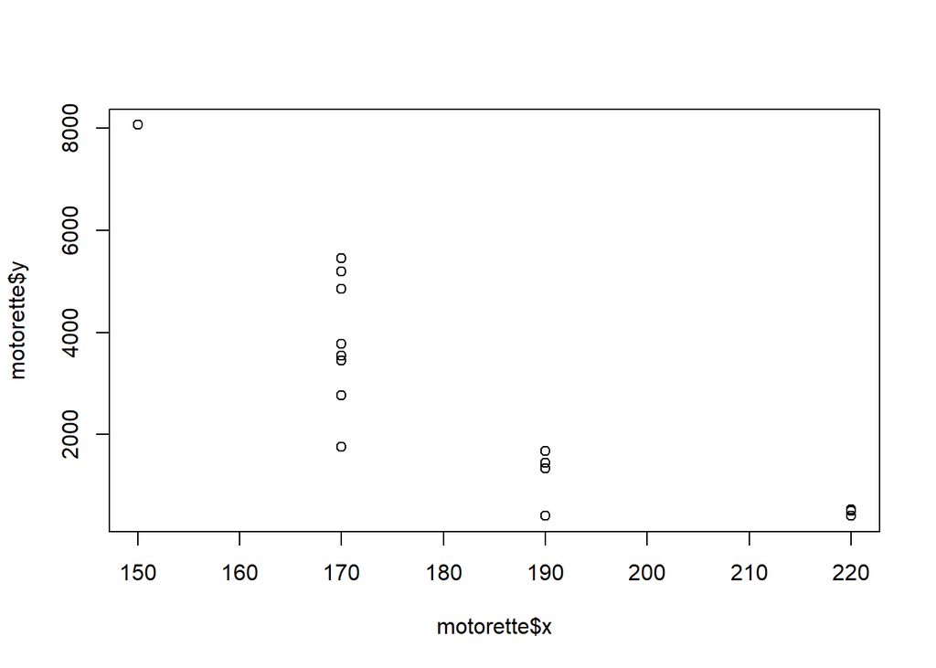

```r
plot(motorette$x, motorette$y)
```

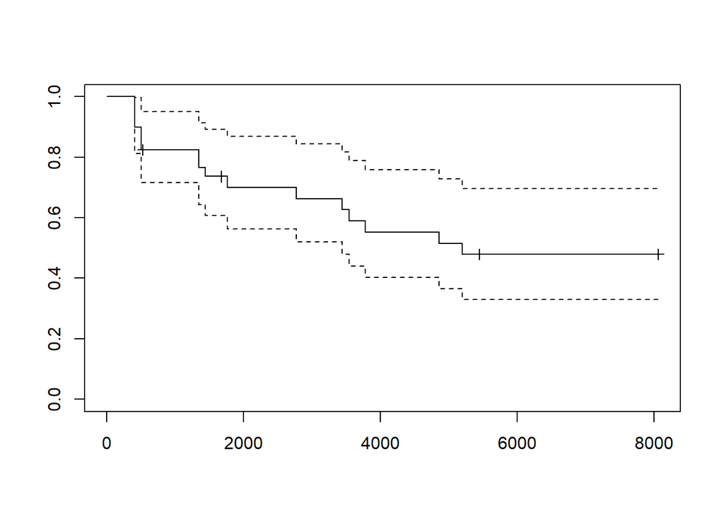

```r
library(survival)

mykm1 <- survfit(Surv(y, cens) ~ 1, data = motorette)

plot(mykm1, mark.time = TRUE)
```

```r
temp_binary = ifelse(motorette$x < 180, "low", "high"); temp_binary
```

```
##  [1] "low"  "low"  "low"  "low"  "low"  "low"  "low"  "low"  "low"  "low"
## [11] "low"  "low"  "low"  "low"  "low"  "low"  "low"  "low"  "low"  "low"
## [21] "high" "high" "high" "high" "high" "high" "high" "high" "high" "high"
## [31] "high" "high" "high" "high" "high" "high" "high" "high" "high" "high"
```

```r
motorette$temp_binary = temp_binary

survival::survdiff(survival::Surv(motorette$y, motorette$cens) ~ motorette$temp_binary)
```

```
## Call:
## survival::survdiff(formula = survival::Surv(motorette$y, motorette$cens) ~
##     motorette$temp_binary)
##
##                             N Observed Expected (O-E)^2/E (O-E)^2/V
## motorette$temp_binary=high 20       10     4.14      8.32      15.7
## motorette$temp_binary=low  20        7    12.86      2.67      15.7
##
##  Chisq= 15.7  on 1 degrees of freedom, p= 7e-05
```

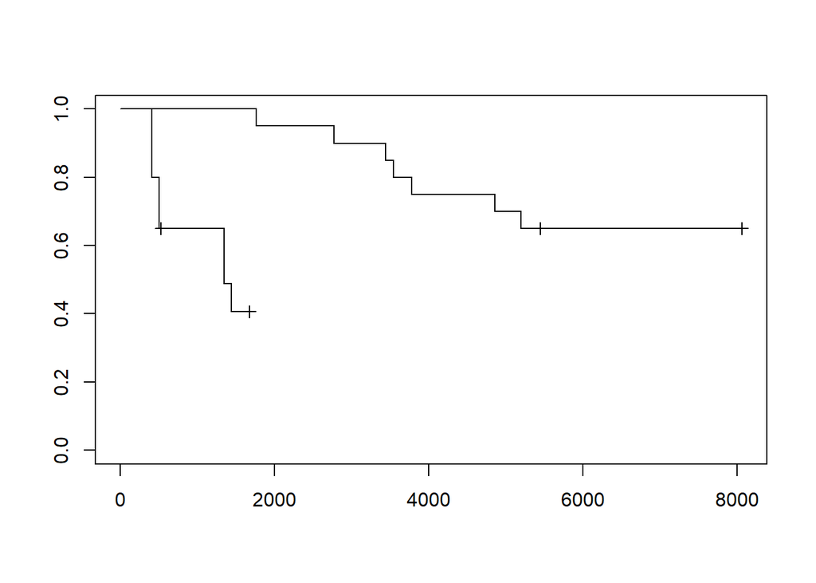

```r
mykm2 <- survfit(Surv(y, cens) ~ temp_binary, data = motorette)

plot(mykm2, mark.time = TRUE)
```

## 2. Improving the model accuracy

### Cox proportional hazards model

1. Hazard rate: The probability estimate of the time it takes for an event to take place
2. Covariates： External factors taht influence the probability of an event
3. The Cox Proportional Hazards Model Equation

$$\lambda(t|X_i) = \lambda_0(t)exp(X_i\beta)\\
h_i(t) = h_0(t)e^{X_i\beta}$$

- $\lambda$ or $h$: The hazard
- $i$: Subject
- $t$: Time point
- $\lambda_0(t)$ or $h_0(t)$: The baseline hazard rate at time point t.
- $\lambda_0(t)$: The baseline hazard
- $exp(X_i\beta)$: Changes of risks based on covariates.

### Introduction of covariates

1. Contribution of covariates
- Covariates are defined prior to data recording
- Accepted data types: Continuous numberic, binary, grouped factor variables.
- Weight of significance is controlled by $\beta$
- Assumptions: It is possible to estimate the effect of the $\beta$ parameters without any consideration of the hazard function
  - The data should be stationary and constant overtime.
2. Implementation of Cox proportional hazards model in R

```r
### Cox Proportional Hazards Model

cox <- coxph(Surv(time, status) ~ treatment + age + sh+ size + index,
             data = prost)

summary(cox)
```

```
## Call:
## coxph(formula = Surv(time, status) ~ treatment + age + sh + size +
##     index, data = prost)
##
##   n= 63, number of events= 23
##
##               coef exp(coef) se(coef)      z Pr(>|z|)
## treatment -0.69695   0.49810  0.53471 -1.303   0.1924
## age       -0.08361   0.91979  0.03692 -2.265   0.0235 *
## sh        -0.23664   0.78927  0.18511 -1.278   0.2011
## size       0.06786   1.07021  0.02833  2.395   0.0166 *
## index      0.77410   2.16865  0.18803  4.117 3.84e-05 ***
## ---
## Signif. codes:  0 '***' 0.001 '**' 0.01 '*' 0.05 '.' 0.1 ' ' 1
##
##           exp(coef) exp(-coef) lower .95 upper .95
## treatment    0.4981     2.0076    0.1747    1.4206
## age          0.9198     1.0872    0.8556    0.9888
## sh           0.7893     1.2670    0.5491    1.1345
## size         1.0702     0.9344    1.0124    1.1313
## index        2.1686     0.4611    1.5002    3.1350
##
## Concordance= 0.866  (se = 0.037 )
## Likelihood ratio test= 38.4  on 5 df,   p=3e-07
## Wald test            = 26.47  on 5 df,   p=7e-05
## Score (logrank) test = 34.47  on 5 df,   p=2e-06
```

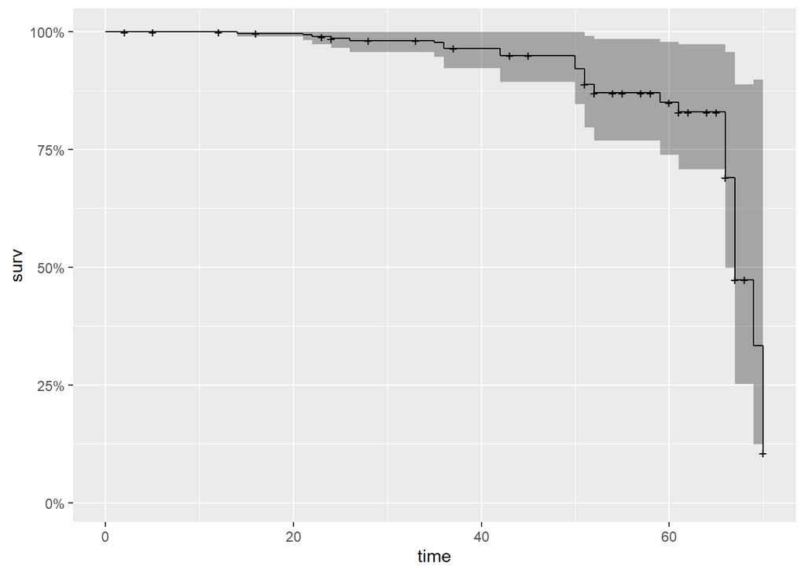

```r
# Getting a plot of the model

autoplot(survfit(cox))
```

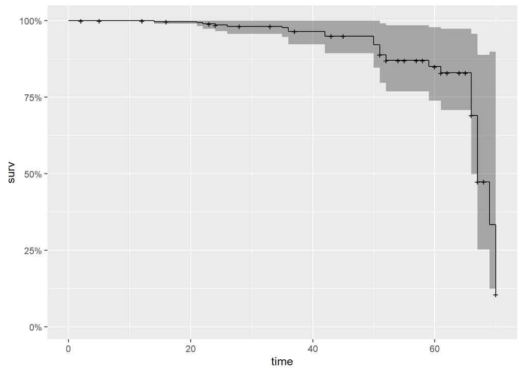

```r
# alternative

coxfit = survfit(cox)

autoplot(coxfit)
```

### Parametric models

1. Distinguish three types of models

```r
library(knitr)
library(kableExtra)

table <- data.frame(Types = c("Non-parametric","Semi-parametric","Parametric"),Baseline_Hazard= c("No distribution assumed","No distribution assumed","Some distribution assumed"), Covariates = c("No distribution assumed","Some distribution assumed","Some distribution assumed"), Examples = c("Kaplan-Meier Estimator","Cox Proportional Hazards Model (covariates with exponential distribution)","Not popular. Parameter selection requires strong reasoning."))

table %>%
  kable() %>%
  kable_styling()
```

| Types | Baseline_Hazard | Covariates | Examples |
| --- | --- | --- | --- |
| Non-parametric | No distribution assumed | No distribution assumed | Kaplan-Meier Estimator |
| Semi-parametric | No distribution assumed | Some distribution assumed | Cox Proportional Hazards Model (covariates with exponential distribution) |
| Parametric | Some distribution assumed | Some distribution assumed | Not popular. Parameter selection requires strong reasoning. |

- Distribution explains how the abservations are distributed in their occurrence.
2. Parametric regression models
- Main distribution types used in survival analysis
  - Exponential: The probability of an event is the same at any time point
  - Gaussian: Event probability is highest around the center of the survival curve
  - Weibull: Allows to set a time on the survival curve (usually at the end where most of the events will likely take place)

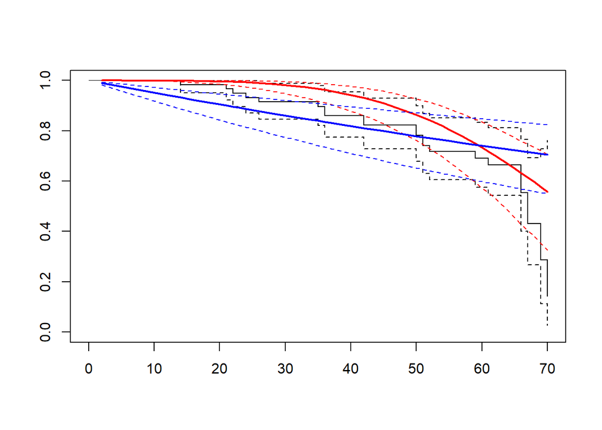

```r
# Parametric models

library(flexsurv)

# Weibull
weib_mod = flexsurvreg(Surv(time, status) ~ treatment + age + sh+ size + index,
                       data = prost, dist = "weibull")

# Exponential
exp_mod = flexsurvreg(Surv(time, status) ~ treatment + age + sh+ size + index,
                      data = prost, dist = "exp")

plot(weib_mod)

lines(exp_mod, col="blue")
```

The black line is Kaplan-Meier Plot. The red curve is under the Weibull distribution and the blue line is under the exponential distribution.

### Aalen’s regressor

1. Covariates and Time
- Cox proportional hazards model improved with covariates
  - The influence of covariates might vary depending on the time point within the study
  - E.g. the size of a tumor
- Modeling the time dependent effects of covariates with Aalen’s additive regression model
  - Function “aareg()” from library “survival”
2. Aalen’s Additive Regression Model

$$H(t) = a(t) + XB(t)$$

- $H(t)$ or $\Lambda(t)$: Cumulative hazard
- $a(t)$: The time dependent intercept term
- $X$: The vector of covariates
- $B(t)$: The time dependent matrix of coefficients
- The result at the tail of the dataset can get inaccurate (risk), because there are naturally only very little subjects left in this study. (called the subjects at risk at the end of the study.)

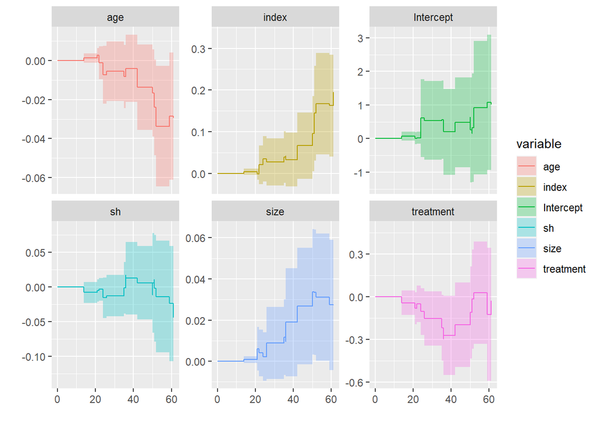

```r
# Aalens additive regression

aalen <- aareg(Surv(time, status) ~ treatment + age + sh+ size + index,
               data = prost)

autoplot(aalen)
```

We find that the index and size covariates have an increasing effect on the hazard rate. This means the longer a subject with a larger tumor or a high tumour index is in this study the more influential these covariates actually get. Higher age gets beneficial after some time (negative effect). sh and treatment stay approximately constant. The effect of intercept increases overtime.

Aalen’s Additive Regression Model should always be used in combination with Cox proportional hazards model.

### Practice

Coding a Cox proportional hazards model and interpreting the results

Dataset: udca1 from ‘survival’ (2.43 or later) (Data from a trial of ursodeoxycholic acid (UDCA) in patients with primary biliary cirrohosis (PBC).)

Fit the model and visualize it, answer the questions:

- Which variables are the most important ones for the model?
- Is there a difference between the two treatment groups?
- How does the survival plot look for the two treatments?
- Can you improve the concordance by eliminating non-significant covariates?

```r
library(dplyr)
data("udca")
glimpse(udca1)
```

```
## Rows: 170
## Columns: 7
## $ id        <int> 1, 2, 3, 4, 5, 6, 7, 8, 9, 10, 11, 12, 13, 14, 15, 16, 17...
## $ trt       <int> 1, 0, 1, 1, 0, 1, 0, 0, 0, 1, 1, 1, 0, 0, 1, 0, 0, 0, 1, ...
## $ stage     <int> 1, 1, 0, 1, 1, 1, 1, 1, 1, 0, 1, 0, 0, 0, 1, 1, 1, 1, 1, ...
## $ bili      <dbl> 1.0, 1.7, 0.5, 1.4, 1.1, 1.4, 0.6, 5.1, 1.6, 0.5, 1.7, 4....
## $ riskscore <dbl> 5.1, 4.2, 3.4, 5.0, 4.3, 5.9, 3.8, 7.4, 5.3, 4.0, 4.5, 7....
## $ futime    <dbl> <array[26]>
## $ status    <dbl> <array[26]>
```

```r
### Exercise Cox Prop Hazards

# Cox Proportional Hazards

cox <- coxph(Surv(futime, status) ~ trt + stage + bili + riskscore,
             data = udca1)
summary(cox)
```

```
## Call:
## coxph(formula = Surv(futime, status) ~ trt + stage + bili + riskscore,
##     data = udca1)
##
##   n= 169, number of events= 72
##    (1 observation deleted due to missingness)
##
##               coef exp(coef) se(coef)      z Pr(>|z|)
## trt       -1.01636   0.36191  0.25628 -3.966 7.31e-05 ***
## stage      0.03453   1.03514  0.28768  0.120   0.9045
## bili       0.08971   1.09385  0.07827  1.146   0.2518
## riskscore  0.30950   1.36275  0.16142  1.917   0.0552 .
## ---
## Signif. codes:  0 '***' 0.001 '**' 0.01 '*' 0.05 '.' 0.1 ' ' 1
##
##           exp(coef) exp(-coef) lower .95 upper .95
## trt          0.3619     2.7631    0.2190    0.5981
## stage        1.0351     0.9661    0.5890    1.8192
## bili         1.0939     0.9142    0.9383    1.2752
## riskscore    1.3628     0.7338    0.9932    1.8699
##
## Concordance= 0.684  (se = 0.031 )
## Likelihood ratio test= 30.32  on 4 df,   p=4e-06
## Wald test            = 29.86  on 4 df,   p=5e-06
## Score (logrank) test = 31.47  on 4 df,   p=2e-06
```

Treatment (trt) is high significant. riskscore is not significant. stage and bili seem not contribute to the model.

There are 169 samples in total(n= 169), the number of events is 72. There is 1 observation deleted due to missingness.

The concordance is 0.684. This could be better. (close to 0.5 is a bad model, close to 1 is good model).

From Likelihood ratio test, Wald test, score(logrank) test, the covariates do have an effect and are an important part of the model since p-values are very small.

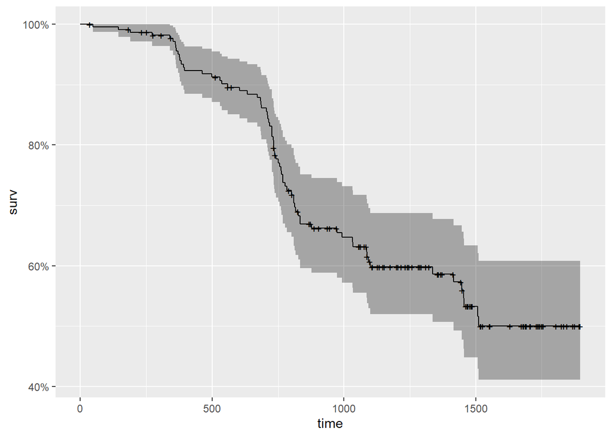

```r
# Getting a plot of the model

autoplot(survfit(cox))
```

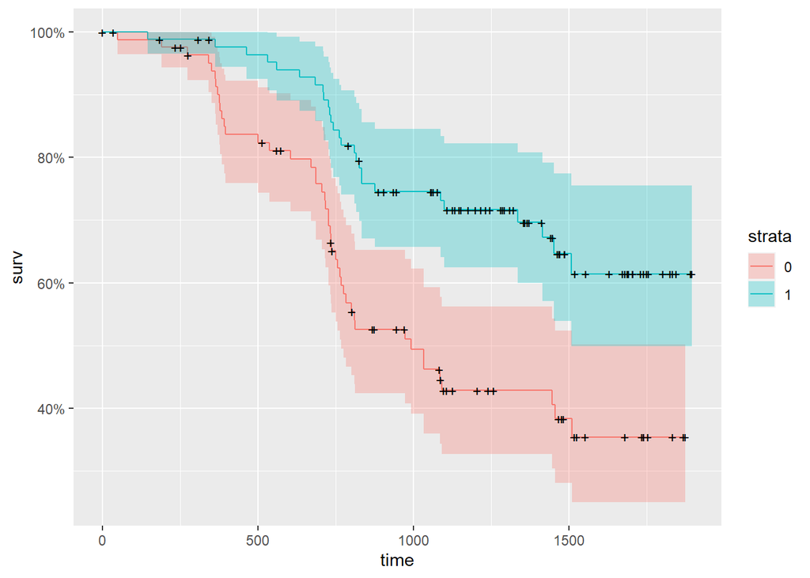

```r
# Standard Kaplan Meier plot to compare the treatments

kmfit <- survfit(Surv(futime, status) ~ trt, data = udca1)

autoplot(kmfit)
```

It is clear that the group with drug has higher survival rate than it with placebo. At the end, the survival rate of group with drug stays in 60% while it of group with placebo stays below 40%.

```r
# Can we improve the concordance by eliminating non significant covariates?

cox2 <- coxph(Surv(futime, status) ~ trt,
              data = udca1)
summary(cox2)
```

```
## Call:
## coxph(formula = Surv(futime, status) ~ trt, data = udca1)
##
##   n= 170, number of events= 72
##
##        coef exp(coef) se(coef)     z Pr(>|z|)
## trt -0.8624    0.4222   0.2443 -3.53 0.000416 ***
## ---
## Signif. codes:  0 '***' 0.001 '**' 0.01 '*' 0.05 '.' 0.1 ' ' 1
##
##     exp(coef) exp(-coef) lower .95 upper .95
## trt    0.4222      2.369    0.2615    0.6815
##
## Concordance= 0.614  (se = 0.029 )
## Likelihood ratio test= 12.99  on 1 df,   p=3e-04
## Wald test            = 12.46  on 1 df,   p=4e-04
## Score (logrank) test = 13.23  on 1 df,   p=3e-04
```

We notice that the concordance has not been improved but decreased. Removing these non significant variables makes the model even worse. This is due to the risk score covariates which has some effect on the model. Overall it is a good idea to leave all the covariance in the model.

## 3. Survival trees

1. Tree Based Survival Model
- Models are pruned to reduce complexity and prevent overfitting
  - Removing sections of the tree that provide little power to classify instances
- Works best on large datasets
- Survival trees are non-linear models
  - Linear assumption: A single line, curve or surface is sufficient to estimate a quantitative response.
  - On some datasets the linear assumption cannot be justified, therefore a non-linear model (Survival tree) can provide better results.
2. Implementation of decision tree in R
- R packages for decision (survival) tree
  - Library “rpart”: toolset for machine learning
  - Library “ranger”: The package used for the demo
- ranger()
  - Grouped variables - Classification tree
  - Numeric variables - Regression tree
  - Survival data - Survival tree

```r
### Survival Trees

library(ranger)

streefit = ranger(Surv(time, status) ~ treatment + age + sh + size + index,
                  data = prost,
                  importance = "permutation",
                  # importance: split rule; "permutation" is a good choice for survival trees
                  splitrule = "extratrees",
                  # splitrule: calculation function for split rule
                  seed = 43)


# Average the survival models

death_times = streefit$unique.death.times
death_times
```

```
##  [1]  2  5 12 14 16 21 22 23 24 26 28 33 35 36 37 42 43 45 50 51 52 54 55 57 58
## [26] 59 60 61 62 64 65 66 67 68 69 70
```

```r
surv_prob = data.frame(streefit$survival)
surv_prob
```

[output not shown]

[output cut: 305 more lines]

```r
avg_prob = sapply(surv_prob,mean)
avg_prob
```

```
##        X1        X2        X3        X4        X5        X6        X7        X8
## 1.0000000 1.0000000 1.0000000 0.9853935 0.9853935 0.9713795 0.9556829 0.9556829
##        X9       X10       X11       X12       X13       X14       X15       X16
## 0.9407342 0.9253622 0.9253622 0.9253622 0.9105269 0.8756178 0.8756178 0.8443062
##       X17       X18       X19       X20       X21       X22       X23       X24
## 0.8443062 0.8443062 0.8130381 0.7775523 0.7570977 0.7570977 0.7570977 0.7570977
##       X25       X26       X27       X28       X29       X30       X31       X32
## 0.7570977 0.7290048 0.7290048 0.7134320 0.7134320 0.7134320 0.7134320 0.6654473
##       X33       X34       X35       X36
## 0.5804907 0.5804907 0.5491556 0.5074379
```

3. Visualize the survival tree
- Plot the survival function for each study participant.
- Plot the average of the survival functions (best and easiest)

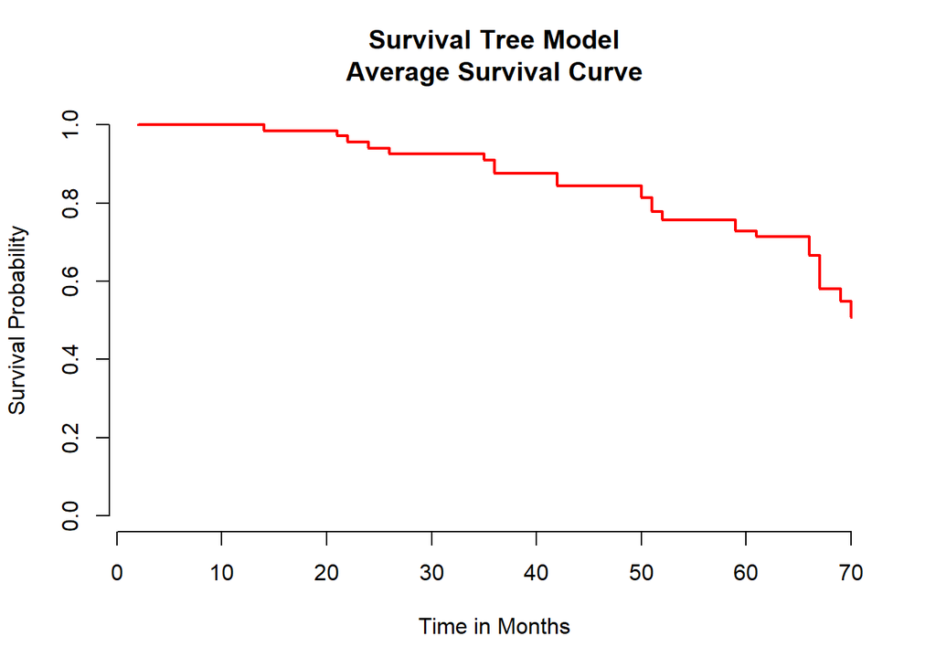

```r
# Plot the survival tree model - average

plot(death_times, avg_prob,
     type = "s", # step plot
     ylim = c(0,1),
     col = "red", lwd = 2, bty = "n",
     ylab = "Survival Probability", xlab = "Time in Months",
     main = "Survival Tree Model\nAverage Survival Curve")
```

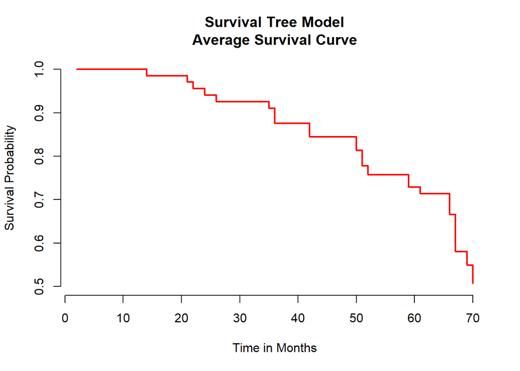

```r
plot(death_times, avg_prob,
     type = "s", # step plot
     ylim = c(0.5,1),
     col = "red", lwd = 2, bty = "n",
     ylab = "Survival Probability", xlab = "Time in Months",
     main = "Survival Tree Model\nAverage Survival Curve")
```

4. Comparison plot
- Our three main models for survival analysis
  - Kaplan-Meier estimator
  - Cox proportional hazards model
  - Survival tree
- Comparison plot of survival models: “ggplot2” + data.frame
  - Extract the relevant information from the models as a data frame (event time and survival probability)
  - Generate one integrated data frame from the extracted data
  - Plot the data frame with “ggplot2”

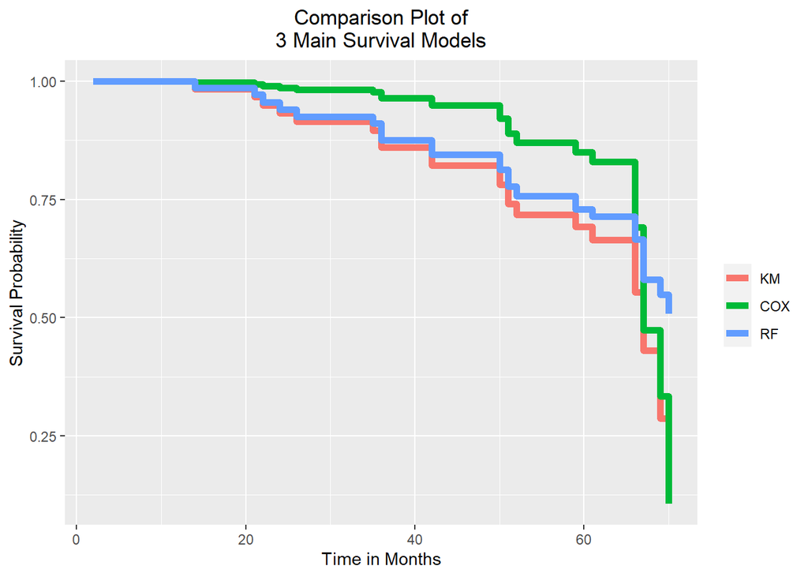

```r
## Comparing the main models we discussed so far

# Set up for ggplot

# Dataframe for KM
mykm1 <- survfit(Surv(time, status) ~ 1, data = prost)

kmdf <- data.frame(mykm1$time,
                   mykm1$surv,
                   KM = rep("KM", 36))
names(kmdf) <- c("Time in Months","Survival Probability","Model")

# Dataframe for Cox PH Model
cox <- coxph(Surv(time, status) ~ treatment + age + sh+ size + index,
             data = prost)
coxfit = survfit(cox)

coxdf <- data.frame(coxfit$time,
                    coxfit$surv,
                    COX = rep("COX", 36))
names(coxdf) <- c("Time in Months","Survival Probability","Model")

# Dataframe for Random Forest
rfdf <- data.frame(death_times,
                   avg_prob,
                   RF = rep("RF", 36))
names(rfdf) <- c("Time in Months","Survival Probability","Model")

# Fusing the dataframe
plotdf <- rbind(kmdf,coxdf,rfdf)

p <- ggplot(plotdf, aes(x = plotdf[,1] ,
                        y = plotdf[,2] ,
                        color = plotdf[,3]))

p + geom_step(size = 2) +
  labs(x = "Time in Months",
       y = "Survival Probability",
       color = "",
       title = "Comparison Plot of\n3 Main Survival Models") +
  theme(plot.title = element_text(hjust = 0.5))
```

The survival rate goes down after 50 months and goes down dramatically after 65 months. RF shows the most positive outlook at the last time point and COX shows the most negative outlook at the last time point.

- Survival tree: works best with huge datasets
- Kaplan-Meier test: No covariates are included
- Cox PH: Covariates are included.

## 4. Date and time handling in R

### Overview

1. The core components of survival data
- Status: indicates if an event happened or not
- Time: how long it took to get to the status
2. Tools for handling dates and time in R
- Standard options available in R base
  - The class POSIXct and POSIXlt
- Library “chron”
- Converting a character into date format with function “strptime()”
  - Dates are often imported as a character (-,:,;,/)
- Library “lubridate”
  - Allow mixed date formats within a column.
  - Calculates the time interval between two time points.

### Working with Dates and Time in R

1. Converting and formatting dates in R
- Things to be considered
  - Time zones
  - Date and time formats
  - Leap years and seconds
- Choosing the most suitable format and converting data between different formats
- Extended R toolbox
  - R base
  - Library ‘lubridate’
2. The class POSIXt
- The class POSIXt: Portable operating system interface for time; encoding system of date and time for most standard computer operating systems.
  - POSIXct
  - POSIXlt

```r
### POSIXt classes in R

x = as.POSIXct("2019-12-25 11:45:34") # nr of seconds

y = as.POSIXlt("2019-12-25 11:45:34")

x; y # it gives the same output, but what is behind it?
```

```
## [1] "2019-12-25 11:45:34 CST"
```

```
## [1] "2019-12-25 11:45:34 CST"
```

```r
unclass(x) # gives a long number
```

```
## [1] 1577245534
## attr(,"tzone")
## [1] ""
```

```r
unclass(y) # gives a list of elements
```

```
## $sec
## [1] 34
##
## $min
## [1] 45
##
## $hour
## [1] 11
##
## $mday
## [1] 25
##
## $mon
## [1] 11
##
## $year
## [1] 119
##
## $wday
## [1] 3
##
## $yday
## [1] 358
##
## $isdst
## [1] 0
##
## $zone
## [1] "CST"
##
## $gmtoff
## [1] NA
```

Unclass of POSIXct gives the amount of seconds. The reference time point for POSIXct is the birth second: 01-01-1970 00:00:00

```r
# what does the number mean?

(50 * 365 * 24 * 60 * 60) - (5.5 * 60 * 60) #
```

```
## [1] 1576780200
```

```r
y$zone # extracting the elements from POSIXlt
```

```
## [1] "CST"
```

```r
# x$zone # not possible since it is simply a number of seconds
```

There are many classes related to POSIXt, such as Date class and chron class.

```r
# another class based on days

x = as.Date("2019-12-25")
x; class(x)
```

```
## [1] "2019-12-25"
```

```
## [1] "Date"
```

```r
unclass(x) # days
```

```
## [1] 18255
```

```r
50 * 365 - 5 # nr of days since 1970
```

```
## [1] 18245
```

```r
library(chron)
x = chron("12/25/2019", "23:34:09")
x
```

```
## [1] (12/25/19 23:34:09)
```

```r
class(x)
```

```
## [1] "chron" "dates" "times"
```

```r
unclass(x)
```

```
## [1] 18255.98
## attr(,"format")
##   dates   times
## "m/d/y" "h:m:s"
## attr(,"origin")
## month   day  year
##     1     1  1970
```

R base classes:

- POSIXct - passed seconds since the birth second
- POSIXlt - date and time components
- Both POSIXct and POSIXlt account for date, time and time zones
- Date - passed days since the birth day

Library “chron”

- chron - practical usage without time zone

### Format conversion from strings to date

- Date/ Time without encoding is read as string
- Function strptime() for converting strings to date time values.

```r
### strptime

?strptime
```

```
## starting httpd help server ... done
```

```r
a = as.character(c("1993-12-30 23:45",
                   "1994-11-05 11:43",
                   "1992-03-09 21:54"))
class(a)
```

```
## [1] "character"
```

```r
b = strptime(a, format = "%Y-%m-%d %H:%M")
b; class(b)
```

```
## [1] "1993-12-30 23:45:00 CST" "1994-11-05 11:43:00 CST"
## [3] "1992-03-09 21:54:00 CST"
```

```
## [1] "POSIXlt" "POSIXt"
```

Format conversion with R base:

- strptime()
- Converts strings into date time or vice versa
- Strings to be converted need to be uniform in their format
- Encoding guide is included in the help section of strptime()

### The Lubridate package

1. library “lubridate”: Convernient toolset for date and time handling
- Date and time based calculations
- Advanced format conversion
- Changing the time zone
- Checking for leap years

```r
### Lets take a look at the package lubridate which has very useful time/date data functions

library(lubridate)

# different ways in how to input dates

ymd(19931123)
```

```
## [1] "1993-11-23"
```

```r
dmy(23111993)
```

```
## [1] "1993-11-23"
```

```r
mdy(11231993)
```

```
## [1] "1993-11-23"
```

```r
# lets use time and date together

mytimepoint <- ymd_hm("1993-11-23 11:23", tz = "Europe/Prague")

mytimepoint
```

```
## [1] "1993-11-23 11:23:00 CET"
```

```r
class(mytimepoint)
```

```
## [1] "POSIXct" "POSIXt"
```

```r
# extracting the components of it

minute(mytimepoint)
```

```
## [1] 23
```

```r
day(mytimepoint)
```

```
## [1] 23
```

```r
hour(mytimepoint)
```

```
## [1] 11
```

```r
year(mytimepoint)
```

```
## [1] 1993
```

```r
month(mytimepoint)
```

```
## [1] 11
```

```r
# we can even change time values within our object

hour(mytimepoint) <- 14

mytimepoint
```

```
## [1] "1993-11-23 14:23:00 CET"
```

```r
# which time zones do we have available

OlsonNames()
```

[output not shown]

[output cut: 284 more lines]

```r
# we can take a look at the most common time zones

# but be aware that the time zone recognition also depends on your location and machine
```

```r
## lets check which day our time point is

wday(mytimepoint) # third day of that week
```

```
## [1] 3
```

```r
wday(mytimepoint, label=T, abbr=F) # label to display the name of the day, no abbreviation
```

```
## [1] Tuesday
## 7 Levels: Sunday < Monday < Tuesday < Wednesday < Thursday < ... < Saturday
```

```r
# we can calculate which time our timepoint would be in another time zone

with_tz(mytimepoint, tz = "Europe/London")
```

```
## [1] "1993-11-23 13:23:00 GMT"
```

```r
mytimepoint
```

```
## [1] "1993-11-23 14:23:00 CET"
```

```r
# time intervals

time1 = ymd_hm("1993-09-23 11:23", tz = "Europe/Prague")

time2 = ymd_hm("1995-11-02 15:23", tz = "Europe/Prague")

# getting the interval

myinterval = interval(time1, time2); myinterval
```

```
## [1] 1993-09-23 11:23:00 CEST--1995-11-02 15:23:00 CET
```

```r
class(myinterval) # interval is an object class from lubridate
```

```
## [1] "Interval"
## attr(,"package")
## [1] "lubridate"
```

### Practice

Create a data frame with separate date and time columns

Measurement: random numbers (10 = mean) rounded to 2 decimal places

Time zone: CET

Try several different input formats for data and time

1. Creating the vectors
- A: date
- B: time
- C: measurement
2. Converting vectors ‘a’ and ‘b’ into date and time formats
3. Combining the vectors into one data framn with “cbind()”

```r
### Exercise: Creating a Data Frame with lubridate

# lets now build a dataframe with lubridate that contains date and time data

# see the different input formats that are allowed in the ymd function

a = c("1998,11,11", "1983/01/23", "1982:09:04", "1945-05-09", 19821224, "1974.12.03", 19871210)

a = ymd(a, tz = "CET") ;a
```

```
## [1] "1998-11-11 CET"  "1983-01-23 CET"  "1982-09-04 CEST" "1945-05-09 CEST"
## [5] "1982-12-24 CET"  "1974-12-03 CET"  "1987-12-10 CET"
```

```r
# now I am creating a time vector - using different notations of input

b = c("22 4 5", "04;09;45", "11:9:56", "23,15,12", "14 16 34", "8 8 23", "21 16 14")

b = hms(b); b
```

```
## [1] "22H 4M 5S"   "4H 9M 45S"   "11H 9M 56S"  "23H 15M 12S" "14H 16M 34S"
## [6] "8H 8M 23S"   "21H 16M 14S"
```

```r
f = rnorm(7,10); f = round(f, digits = 2); f
```

```
## [1]  7.93 11.08 10.71  8.93  9.69  8.95 10.20
```

```r
date_time_measurement = cbind.data.frame(date = a, time = b, measurement = f)

date_time_measurement
```

```
##         date        time measurement
## 1 1998-11-11   22H 4M 5S        7.93
## 2 1983-01-23   4H 9M 45S       11.08
## 3 1982-09-04  11H 9M 56S       10.71
## 4 1945-05-09 23H 15M 12S        8.93
## 5 1982-12-24 14H 16M 34S        9.69
## 6 1974-12-03   8H 8M 23S        8.95
## 7 1987-12-10 21H 16M 14S       10.20
```